# Principal Component Analysis (PCA)

### For $ \lambda_2 \approx 4.795 $:

$ \begin{bmatrix} 2.505 & 10.95 \\ 10.95 & 515.205 \end{bmatrix} \mathbf{v}_2 = \mathbf{0} $

We solve this system of equations by setting up the equations:

$ 2.505 v_{2_1} + 10.95 v_{2_2} = 0 $ $ 10.95 v_{2_1} + 515.205 v_{2_2} = 0 $

From the first equation, we can express $ v_{2_1} $ in terms of $ v_{2_2} $: $ v_{2_1} = -\frac{10.95}{2.505} v_{2_2} $

Substituting this expression into the second equation: $ 10.95 \left(-\frac{10.95}{2.505}\right) v_{2_2} + 515.205 v_{2_2} = 0 $

$ -120.125 v_{2_2} + 515.205 v_{2_2} = 0 $

$ 395.08 v_{2_2} = 0 $

This implies that $ v_{2_2} = 0 $.

So, $ v_{2_1} = -\frac{10.95}{2.505} \times 0 = 0 $.

So, we have found the eigenvectors corresponding to the eigenvalues $ \lambda_1 \approx 522.505 $ and $ \lambda_2 \approx 4.795 $.

In Step 4, we select the principal components based on the eigenvectors corresponding to the highest eigenvalues.

For our example, we found two eigenvalues:

1. $ \lambda_1 \approx 522.505 $
2. $ \lambda_2 \approx 4.795 $

The corresponding eigenvectors are:

Now, since $ \lambda_1 $ is much larger than $ \lambda_2 $, we choose the eigenvector corresponding to $ \lambda_1 $ as the first principal component, and the eigenvector corresponding to $ \lambda_2 $ as the second principal component.

So, our principal components are:

These principal components capture the directions of maximum variance in the data. The first principal component ($ \mathbf{v}_1 $) corresponds to the direction in which the data varies the most, while the second principal component ($ \mathbf{v}_2 $) captures the remaining variance orthogonal to the first component.

In Step 5, we project the original data onto the selected principal components to obtain the reduced-dimensional representation.

Let's denote the original centered data matrix as $ X' $, where each row represents an individual data point and each column represents a feature. In our case, $ X' $ will be a $ 5 \times 2 $ matrix.

$ X' = \begin{bmatrix} -1.4 & -17 \\ 1.6 & 13 \\ -3.4 & -22 \\ 3.6 & 33 \\ -0.4 & -7 \end{bmatrix} $

And let's denote the principal components matrix as $ V $, where each column represents a principal component. In our case, $ V $ will be a $ 2 \times 2 $ matrix.

To project the data onto the principal components, we simply multiply the data matrix $ X' $ by the principal components matrix $ V $:

$ X_{\text{projected}} = X' \times V $

$ X_{\text{projected}} = \begin{bmatrix} -1.4 & -17 \\ 1.6 & 13 \\ -3.4 & -22 \\ 3.6 & 33 \\ -0.4 & -7 \end{bmatrix} \times \begin{bmatrix} 0 & 1 \\ 1 & 0 \end{bmatrix} $

$ X_{\text{projected}} = \begin{bmatrix} -1.4(0) + (-17)(1) & -1.4(1) + (-17)(0) \\ 1.6(0) + 13(1) & 1.6(1) + 13(0) \\ -3.4(0) + (-22)(1) & -3.4(1) + (-22)(0) \\ 3.6(0) + 33(1) & 3.6(1) + 33(0) \\ -0.4(0) + (-7)(1) & -0.4(1) + (-7)(0) \end{bmatrix} $

This represents the reduced-dimensional representation of the original data using the principal components. Each row in this matrix corresponds to a data point, and each column corresponds to a principal component.

```python
import numpy as np

# Original centered data matrix
X = np.array([
    [-1.4, -17],
    [1.6, 13],
    [-3.4, -22],
    [3.6, 33],
    [-0.4, -7]
])

# Compute covariance matrix
covariance_matrix = np.cov(X, rowvar=False)

# Find eigenvalues and eigenvectors
eigenvalues, eigenvectors = np.linalg.eig(covariance_matrix)

# Sort eigenvalues and corresponding eigenvectors
sorted_indices = np.argsort(eigenvalues)[::-1]
eigenvalues = eigenvalues[sorted_indices]
eigenvectors = eigenvectors[:, sorted_indices]

# Select principal components
principal_components = eigenvectors[:, :2]

# Project data onto principal components
X_projected = np.dot(X, principal_components)

print("Original Data:")
print(X)
print("\nProjected Data:")
print(X_projected)
```

```
Original Data:
[[ -1.4 -17. ]
 [  1.6  13. ]
 [ -3.4 -22. ]
 [  3.6  33. ]
 [ -0.4  -7. ]]

Projected Data:
[[ 17.04811985  -0.56710647]
 [-13.09776681  -0.09221966]
 [ 22.2451806    0.84376543]
 [-33.19502459   0.22437155]
 [  6.99949096  -0.40881086]]
```

| Size (sqft) | Bedrooms | Age (years) | Distance to School (miles) | Distance to City Center (miles) | Price (\$1000) |
| --- | --- | --- | --- | --- | --- |
| 2104 | 3 | 5 | 1.2 | 10.6 | 399.9 |
| 1600 | 3 | 12 | 0.8 | 8.2 | 329.9 |
| 2400 | 3 | 8 | 1.5 | 12.5 | 369.0 |
| 1416 | 2 | 2 | 1.0 | 9.0 | 232.0 |
| 3000 | 4 | 10 | 1.3 | 14.0 | 539.9 |
| 1985 | 4 | 15 | 0.9 | 11.0 | 299.9 |
| 1534 | 3 | 6 | 1.1 | 10.2 | 314.9 |
| 1427 | 3 | 3 | 0.7 | 8.5 | 198.9 |
| 1380 | 3 | 4 | 0.8 | 9.3 | 212.0 |
| 1494 | 3 | 7 | 1.0 | 10.0 | 242.0 |

Let's perform PCA on this dataset and visualize the original and projected data points. The steps will be similar to the previous example, but with more features.

This code will plot the original data points in blue and the projected data points in red on the 3D scatter plot. This visualization will help us understand how PCA has reduced the dimensionality of the data while retaining the most important information.

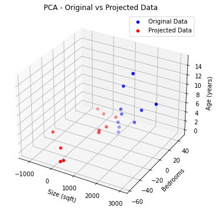

```python
import numpy as np
import matplotlib.pyplot as plt

# Original data
X = np.array([
    [2104, 3, 5, 1.2, 10.6, 399.9],
    [1600, 3, 12, 0.8, 8.2, 329.9],
    [2400, 3, 8, 1.5, 12.5, 369.0],
    [1416, 2, 2, 1.0, 9.0, 232.0],
    [3000, 4, 10, 1.3, 14.0, 539.9],
    [1985, 4, 15, 0.9, 11.0, 299.9],
    [1534, 3, 6, 1.1, 10.2, 314.9],
    [1427, 3, 3, 0.7, 8.5, 198.9],
    [1380, 3, 4, 0.8, 9.3, 212.0],
    [1494, 3, 7, 1.0, 10.0, 242.0]
])

# Center the data
X_centered = X - np.mean(X, axis=0)

# Compute covariance matrix
covariance_matrix = np.cov(X_centered, rowvar=False)

# Find eigenvalues and eigenvectors
eigenvalues, eigenvectors = np.linalg.eig(covariance_matrix)

# Sort eigenvalues and corresponding eigenvectors
sorted_indices = np.argsort(eigenvalues)[::-1]
eigenvalues = eigenvalues[sorted_indices]
eigenvectors = eigenvectors[:, sorted_indices]

# Select principal components
num_principal_components = 2
principal_components = eigenvectors[:, :num_principal_components]

# Project data onto principal components
X_projected = np.dot(X_centered, principal_components)

# Plot original data
fig = plt.figure(figsize=(10, 6))
ax = fig.add_subplot(111, projection='3d')
ax.scatter(X[:, 0], X[:, 1], X[:, 2], color='blue', label='Original Data')

# Plot projected data
ax.scatter(X_projected[:, 0], X_projected[:, 1], np.zeros_like(X_projected[:, 1]), color='red', label='Projected Data')

ax.set_xlabel('Size (sqft)')
ax.set_ylabel('Bedrooms')
ax.set_zlabel('Age (years)')
ax.set_title('PCA - Original vs Projected Data')
ax.legend()
plt.show()
```

The output consists of a 3D scatter plot that visualizes the original data points (in blue) and the projected data points (in red) after applying PCA.

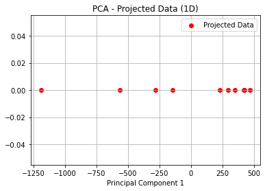

```python
import numpy as np
import matplotlib.pyplot as plt

# Original data
X = np.array([
    [2104, 3, 5, 1.2, 10.6, 399.9],
    [1600, 3, 12, 0.8, 8.2, 329.9],
    [2400, 3, 8, 1.5, 12.5, 369.0],
    [1416, 2, 2, 1.0, 9.0, 232.0],
    [3000, 4, 10, 1.3, 14.0, 539.9],
    [1985, 4, 15, 0.9, 11.0, 299.9],
    [1534, 3, 6, 1.1, 10.2, 314.9],
    [1427, 3, 3, 0.7, 8.5, 198.9],
    [1380, 3, 4, 0.8, 9.3, 212.0],
    [1494, 3, 7, 1.0, 10.0, 242.0]
])

# Center the data
X_centered = X - np.mean(X, axis=0)

# Compute covariance matrix
covariance_matrix = np.cov(X_centered, rowvar=False)

# Find eigenvalues and eigenvectors
eigenvalues, eigenvectors = np.linalg.eig(covariance_matrix)

# Sort eigenvalues and corresponding eigenvectors
sorted_indices = np.argsort(eigenvalues)[::-1]
eigenvalues = eigenvalues[sorted_indices]
eigenvectors = eigenvectors[:, sorted_indices]

# Select principal components
num_principal_components = 1 # Change to 1 or 2 for 1D or 2D projection, respectively
principal_components = eigenvectors[:, :num_principal_components]

# Project data onto principal components
X_projected = np.dot(X_centered, principal_components)

# Plot projected data
plt.scatter(X_projected[:, 0], np.zeros_like(X_projected[:, 0]), color='red', label='Projected Data')

plt.xlabel('Principal Component 1')
plt.title('PCA - Projected Data (1D)')
plt.legend()
plt.grid(True)
plt.show()
```

The output of the code will be a scatter plot representing the reduced-dimensional data after performing PCA. Here's how to interpret the plot:

- **Principal Component 1 Axis**: This axis represents the first principal component obtained from PCA. Each point on this axis corresponds to the projection of a data point onto the first principal component. The first principal component captures the direction of maximum variance in the original data.
- **Projected Data Points (Red)**: Each red point in the plot represents a data point after projecting the original data onto the first principal component. These points are the reduced-dimensional representation of the original data in 1D space. The position of each point along the Principal Component 1 axis represents its projection onto this component.
- **Interpretation**: The scatter plot shows how the original high-dimensional data has been compressed into 1D space while preserving the most significant variation. The distribution of the red points along the Principal Component 1 axis gives insight into the structure and variability of the dataset in this reduced-dimensional representation. Points that are closer together in the plot correspond to data points that are more similar in the original high-dimensional space, while points that are further apart represent greater dissimilarity.

In the context of PCA, the principal component axes themselves are not directly associated with any specific original features. Instead, each principal component axis is a linear combination of all the original features in the dataset.

The first principal component axis (PC1) represents the direction in the high-dimensional feature space along which the data exhibits the maximum variance. It is a new axis or direction that captures the most significant patterns or variability in the data.

Therefore, it's not accurate to say that a specific feature corresponds to the PC1 axis. Rather, PC1 is a weighted combination of all the original features, and each feature contributes differently to PC1 based on its covariance with other features in the dataset. The weights or coefficients associated with each original feature in the PC1 axis indicate their relative importance in defining the direction of maximum variance in the data.